# White Wine Quality Exploration by Mehmet Saruhan

This report explores a dataset containing approximately 4900 wine quality measurement. Detailed information about dataset and variables can found in WineQualityInfo.txt.

# Univariate Plots Section

```
## [1] 4898   13
```

```
## 'data.frame':    4898 obs. of  13 variables:
##  $ X                   : int  1 2 3 4 5 6 7 8 9 10 ...
##  $ fixed.acidity       : num  7 6.3 8.1 7.2 7.2 8.1 6.2 7 6.3 8.1 ...
##  $ volatile.acidity    : num  0.27 0.3 0.28 0.23 0.23 0.28 0.32 0.27 0.3 0.22 ...
##  $ citric.acid         : num  0.36 0.34 0.4 0.32 0.32 0.4 0.16 0.36 0.34 0.43 ...
##  $ residual.sugar      : num  20.7 1.6 6.9 8.5 8.5 6.9 7 20.7 1.6 1.5 ...
##  $ chlorides           : num  0.045 0.049 0.05 0.058 0.058 0.05 0.045 0.045 0.049 0.044 ...
##  $ free.sulfur.dioxide : num  45 14 30 47 47 30 30 45 14 28 ...
##  $ total.sulfur.dioxide: num  170 132 97 186 186 97 136 170 132 129 ...
##  $ density             : num  1.001 0.994 0.995 0.996 0.996 ...
##  $ pH                  : num  3 3.3 3.26 3.19 3.19 3.26 3.18 3 3.3 3.22 ...
##  $ sulphates           : num  0.45 0.49 0.44 0.4 0.4 0.44 0.47 0.45 0.49 0.45 ...
##  $ alcohol             : num  8.8 9.5 10.1 9.9 9.9 10.1 9.6 8.8 9.5 11 ...
##  $ quality             : int  6 6 6 6 6 6 6 6 6 6 ...
```

```
##        X        fixed.acidity    volatile.acidity  citric.acid
##  Min.   :   1   Min.   : 3.800   Min.   :0.0800   Min.   :0.0000
##  1st Qu.:1225   1st Qu.: 6.300   1st Qu.:0.2100   1st Qu.:0.2700
##  Median :2450   Median : 6.800   Median :0.2600   Median :0.3200
##  Mean   :2450   Mean   : 6.855   Mean   :0.2782   Mean   :0.3342
##  3rd Qu.:3674   3rd Qu.: 7.300   3rd Qu.:0.3200   3rd Qu.:0.3900
##  Max.   :4898   Max.   :14.200   Max.   :1.1000   Max.   :1.6600
##  residual.sugar     chlorides       free.sulfur.dioxide
##  Min.   : 0.600   Min.   :0.00900   Min.   :  2.00
##  1st Qu.: 1.700   1st Qu.:0.03600   1st Qu.: 23.00
##  Median : 5.200   Median :0.04300   Median : 34.00
##  Mean   : 6.391   Mean   :0.04577   Mean   : 35.31
##  3rd Qu.: 9.900   3rd Qu.:0.05000   3rd Qu.: 46.00
##  Max.   :65.800   Max.   :0.34600   Max.   :289.00
##  total.sulfur.dioxide    density             pH          sulphates
##  Min.   :  9.0        Min.   :0.9871   Min.   :2.720   Min.   :0.2200
##  1st Qu.:108.0        1st Qu.:0.9917   1st Qu.:3.090   1st Qu.:0.4100
##  Median :134.0        Median :0.9937   Median :3.180   Median :0.4700
##  Mean   :138.4        Mean   :0.9940   Mean   :3.188   Mean   :0.4898
##  3rd Qu.:167.0        3rd Qu.:0.9961   3rd Qu.:3.280   3rd Qu.:0.5500
##  Max.   :440.0        Max.   :1.0390   Max.   :3.820   Max.   :1.0800
##     alcohol         quality
##  Min.   : 8.00   Min.   :3.000
##  1st Qu.: 9.50   1st Qu.:5.000
##  Median :10.40   Median :6.000
##  Mean   :10.51   Mean   :5.878
##  3rd Qu.:11.40   3rd Qu.:6.000
##  Max.   :14.20   Max.   :9.000
```

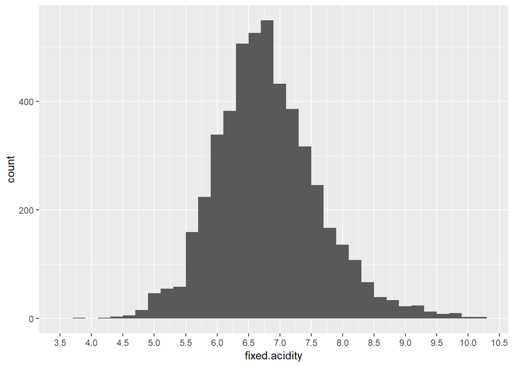

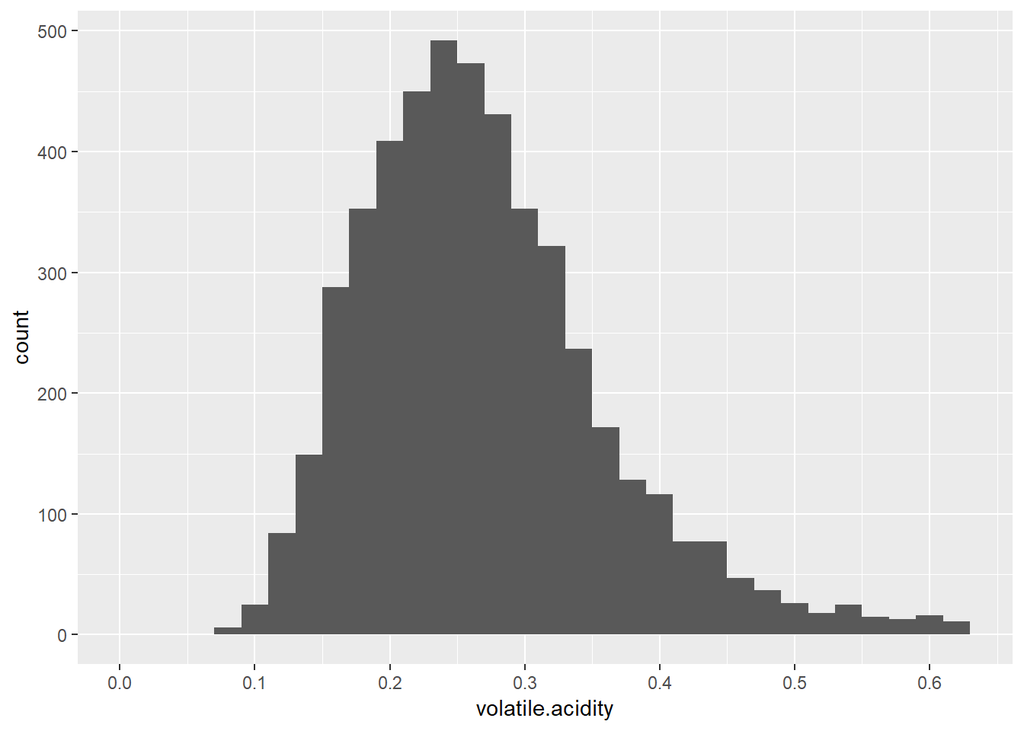

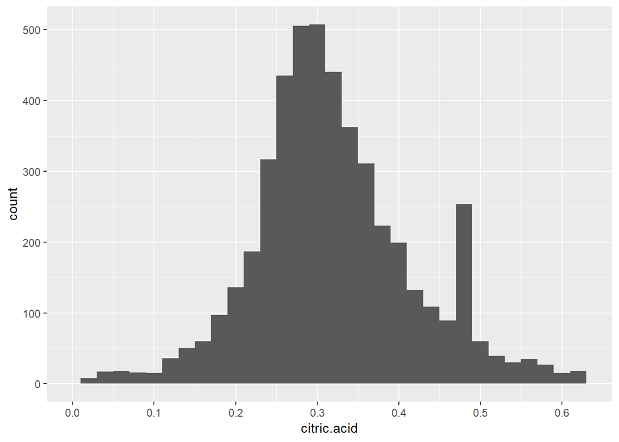

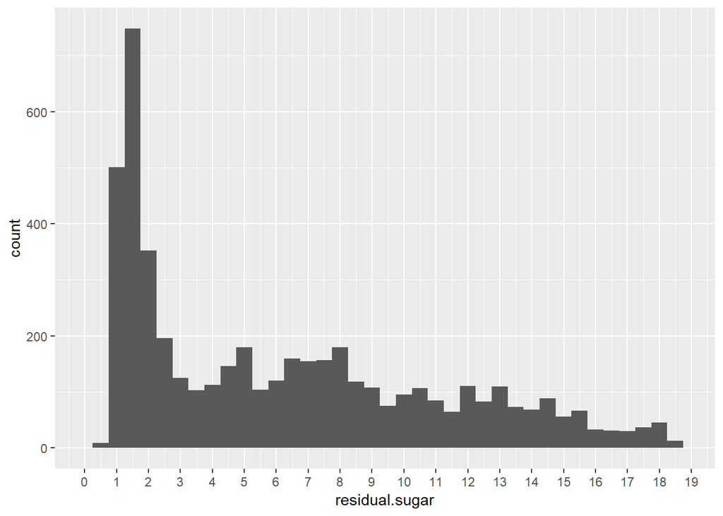

Sugar levels peaks at values smaller than 3.Graphs look like an exponential distribution. Let`s look at the log10 of count plot.

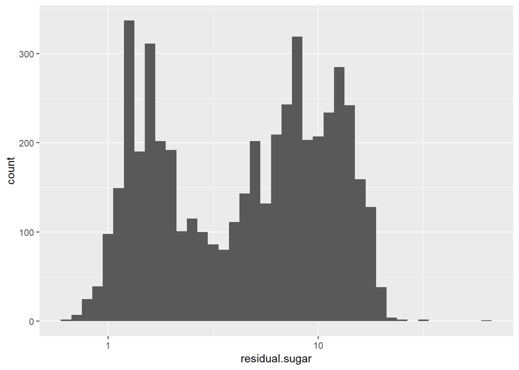

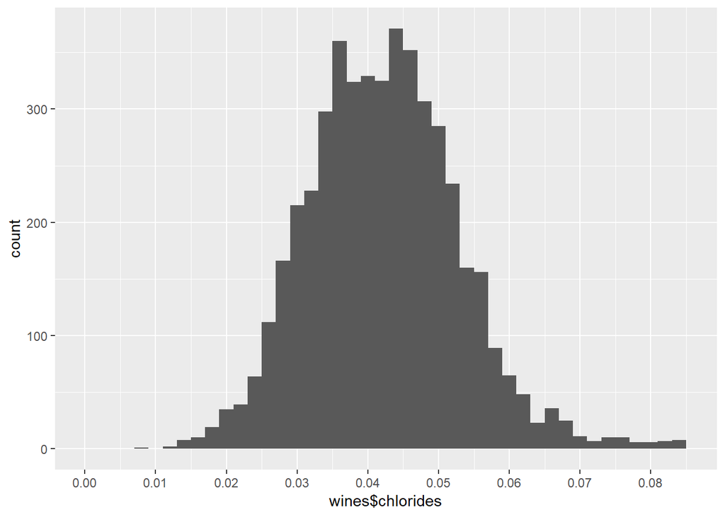

Chlorides graph shows normal distribution. %3 of high values are ommitted.

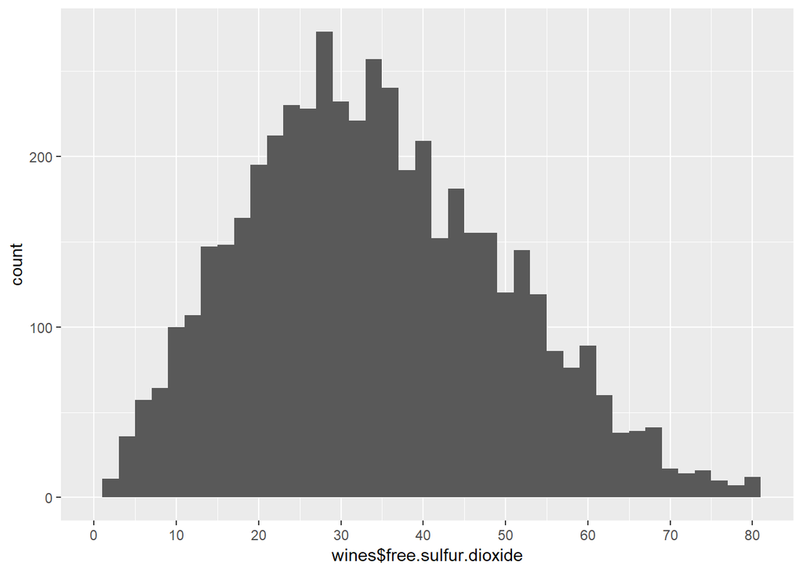

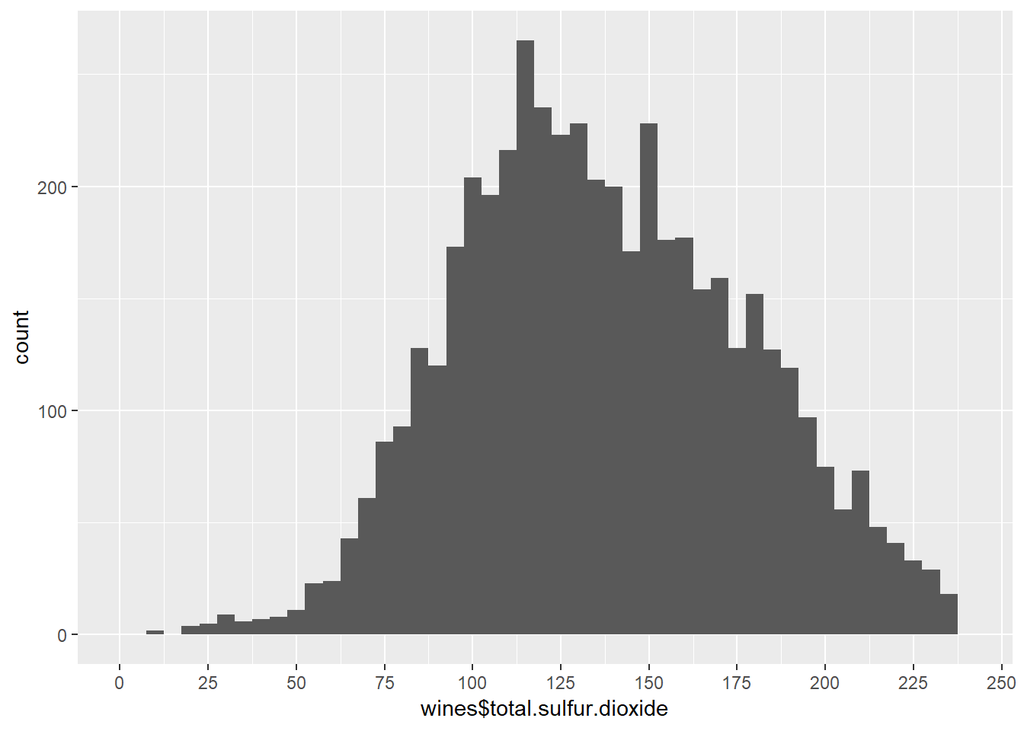

Free and total sulfur dioxide graphs show a normal distribution. Free sulfur dioxide peaks around 30, total sulfur dioxide peaks around 110. There can be a high correlation between these graphs. %1 of high values omitted for better readability.

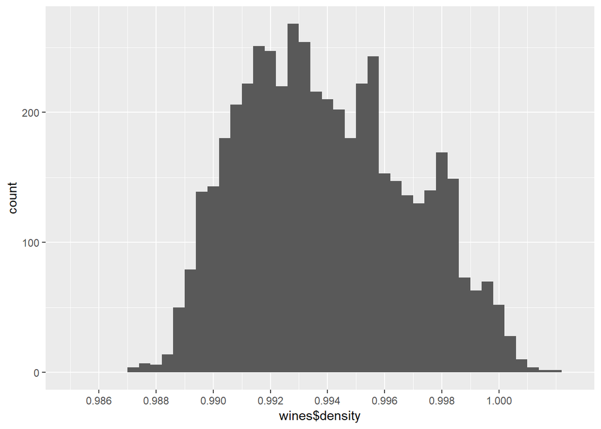

%0,1 of values omitted for readability of the graph. Density shows normal distribution. There are small peaks around 0.995 and 0.998.

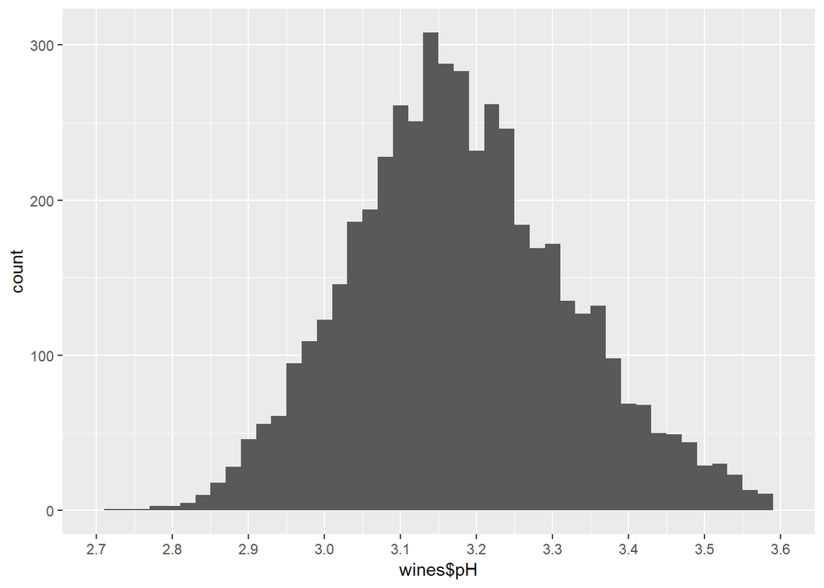

%0,1 of values omitted for readability of the graph. pH shows a normal distribution. pH is related to acidity so we can have a high correlation between acidity levels.

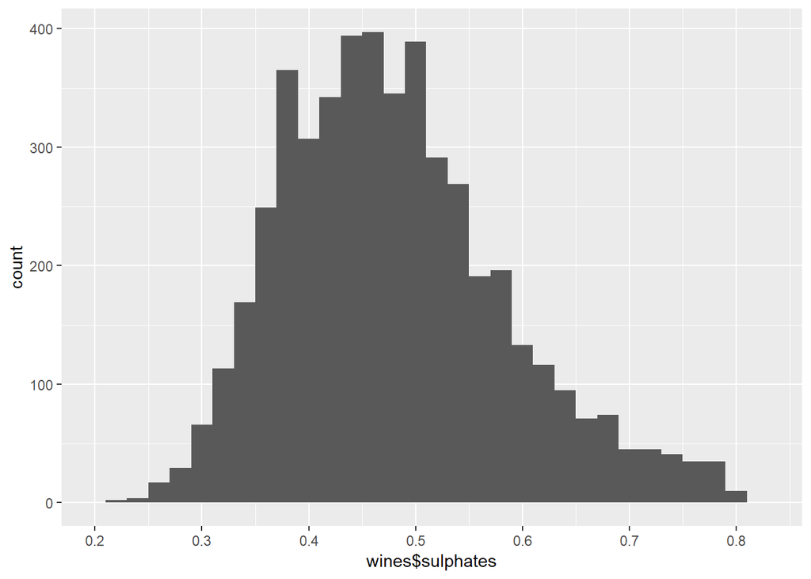

%1 of high values omiitted. Sulphates graph shows normal distribution.

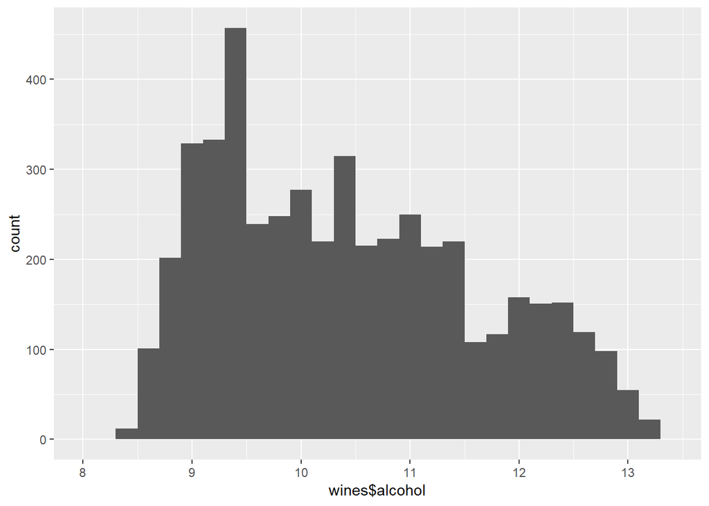

%1 of high values are omitted. Alcohol graph seems like biomodial or even trimodial peaks around 9.5,10.5, 12.5.

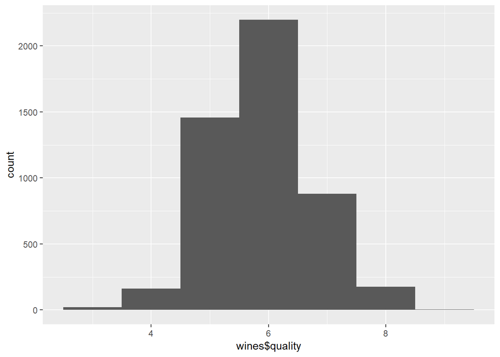

The quality graph shows a normal distribution. Since there is very little data about quality values 3 and 9, I am going to omit these values.

# Univariate Analysis

### What is the structure of your dataset?

Dataset Contains 4898 observations over 13 variables. All variables are numerical including the quality. Quality mostly will be considered as a factor through analysis.

### What is/are the main feature(s) of interest in your dataset?

In white wine dataset main interest is the quality of the wine. Through analysis, my primary concern will be the relation between quality and other variables in the dataset.

### What other features in the dataset do you think will help support your

investigation into your feature(s) of interest?

According to an article “Great wines are in balance with their four fundamental traits (Acidity, tannin, alcohol, and sweetness) and as wines age, the acidity acts as a buffer to preserve the wine longer.” Tannin is at deficient levels in white wines so our analysis will base on variables of Acidity, Alcohol, and Sweetness.

### Did you create any new variables from existing variables in the dataset?

To analyze acidity, I combined all acid variables and created total_acidity.

### Of the features you investigated, were there any unusual distributions? Did you perform any operations on the data to tidy, adjust, or change the form of the data? If so, why did you do this?

# Bivariate Plots Section

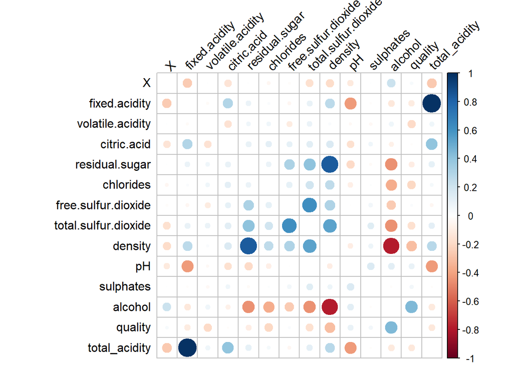

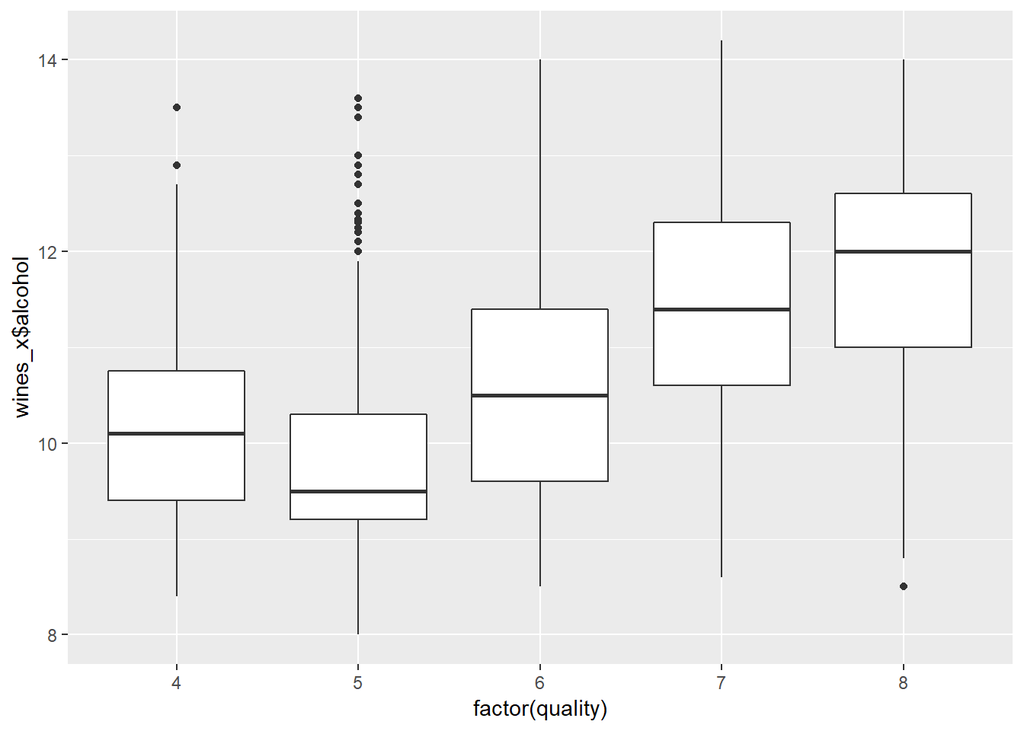

According to this graph wines quality level increases with the amount of alcohol.

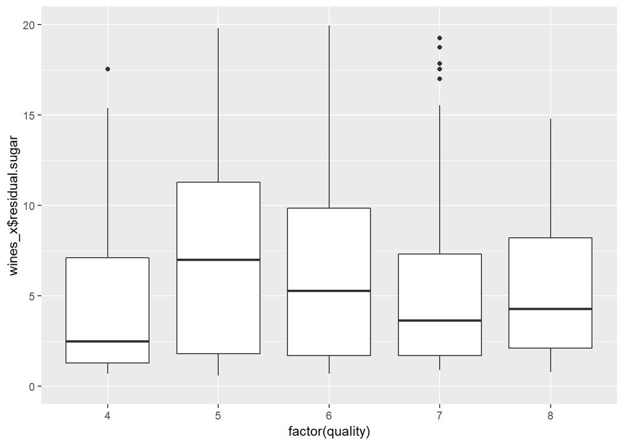

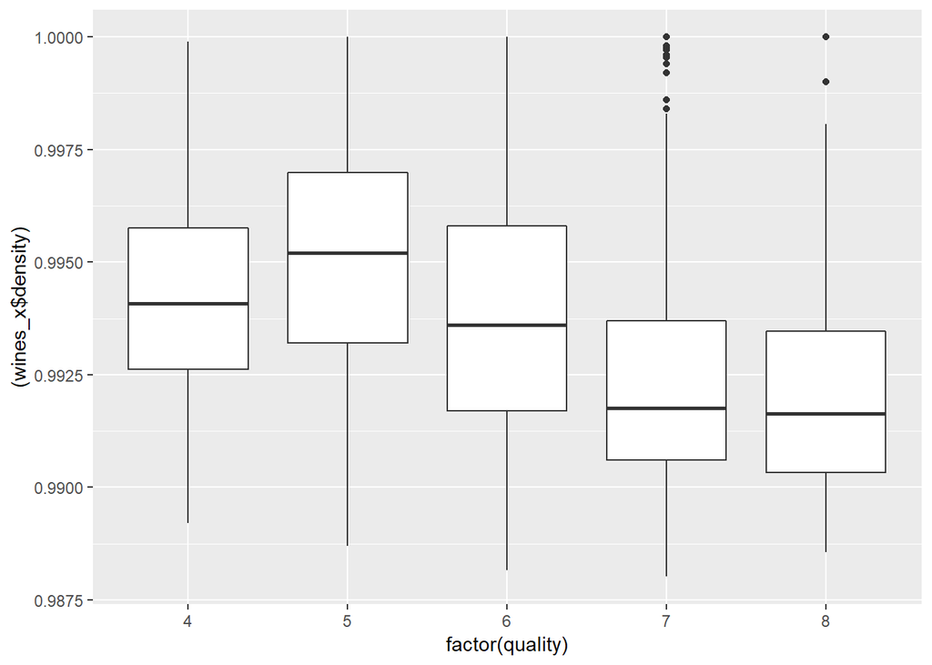

Higher quality wines tend to have lower densities and high amount of alcohol. Does density decrease with the amount of alcohol?

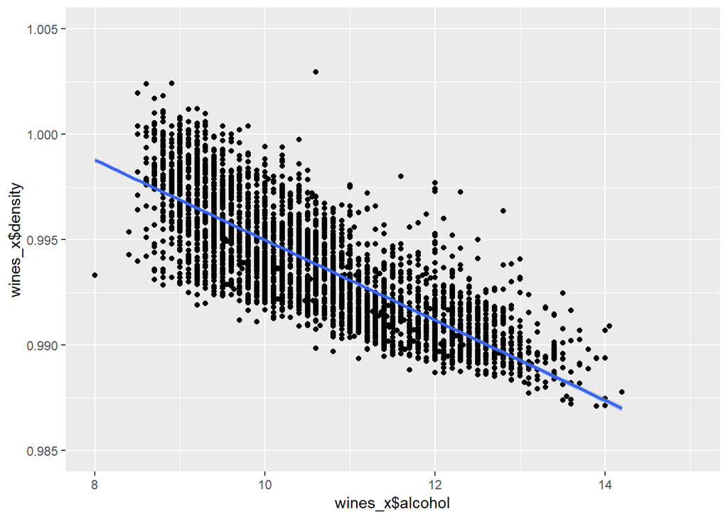

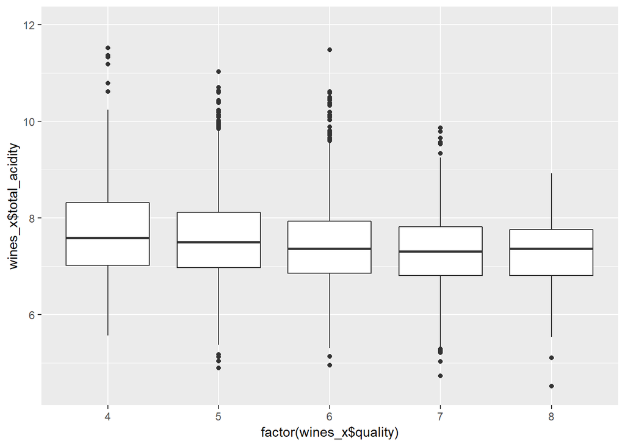

Total acidity decreases as the quality increase.Difference is minimal among qualities.

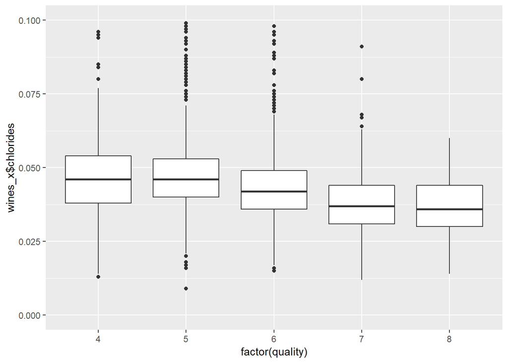

Higher quality wines have less chlorides.

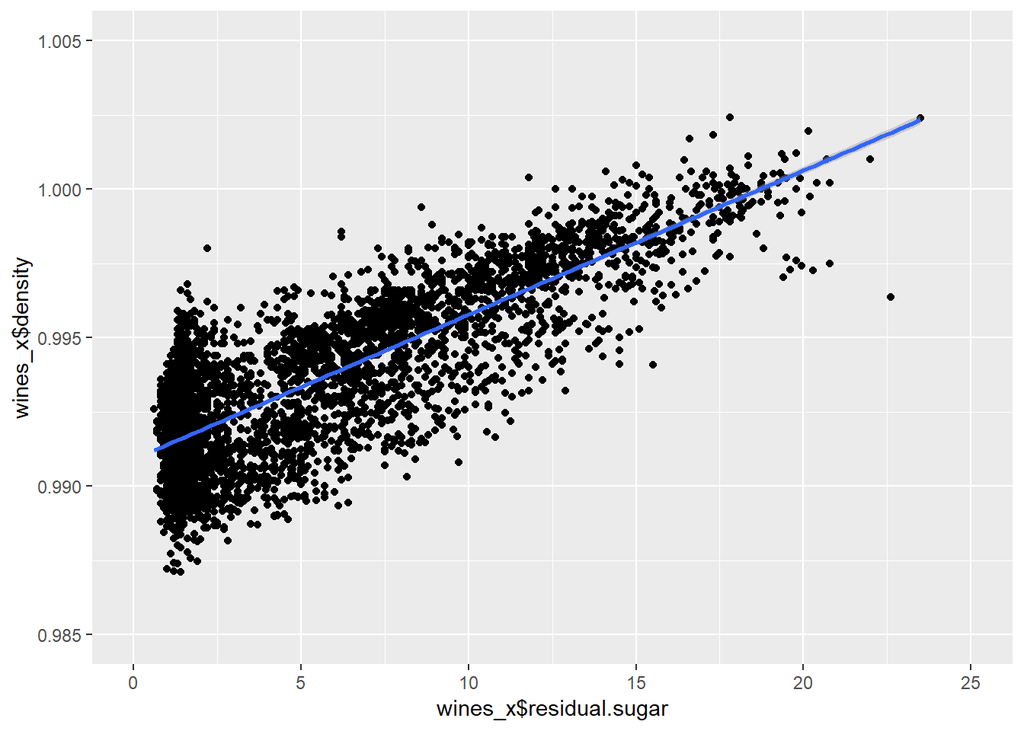

Density increases with the amount of sugar.

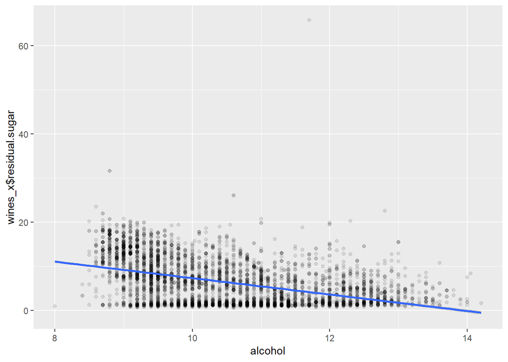

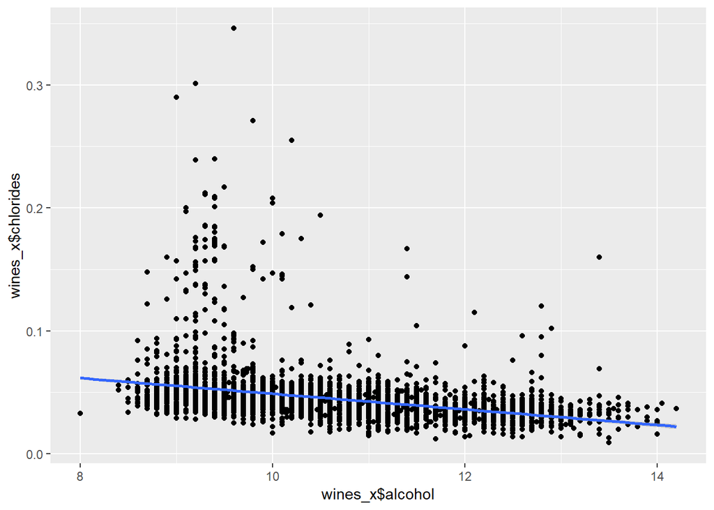

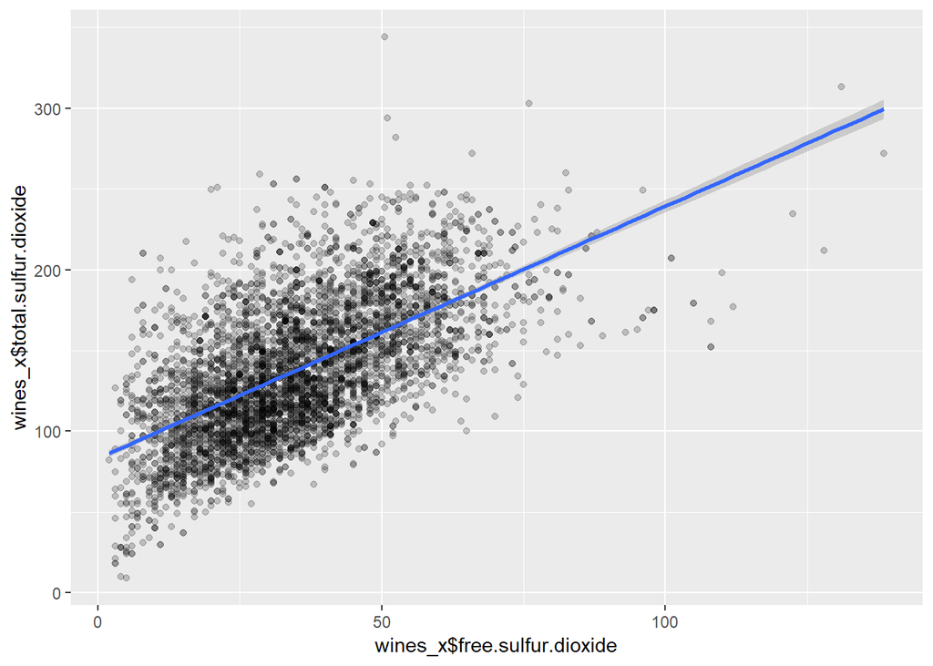

Amount of free sulfur dioxide increases with total sulfur dioxide as expected.

# Bivariate Analysis

### Talk about some of the relationships you observed in this part of the investigation. How did the feature(s) of interest vary with other features in the dataset?

The most apparent relation is High-quality wines contain more alcohol percentage. For acidity and residual sugar levels, there is no clear tendency. I think there is a balance between Residual sugar, acidity, and alcohol. Density is lower at high-quality wines. I am curious about the relation of quality with alcohol level to sugar ratio.

### Did you observe any interesting relationships between the other features (not the main feature(s) of interest)?

The most interesting relationship was between free and total sulfur dioxide. I expect the correlation to be higher.

### What was the strongest relationship you found?

The strongest relationship is between residual sugar and density.

# Multivariate Plots Section

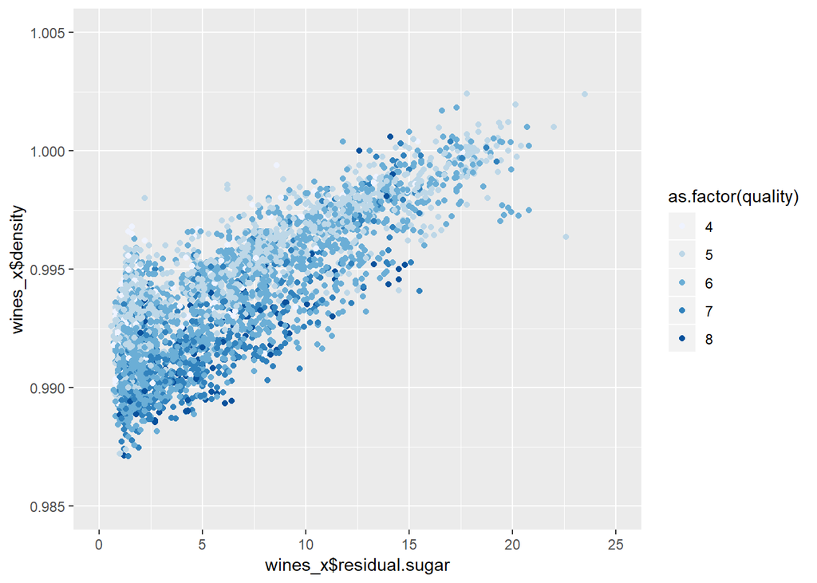

This graph shows that wines with lower densities are more likely to be better at the same sugar levels. Density lowers with alcohol level so wine should contain more alcohol at the same sugar level.

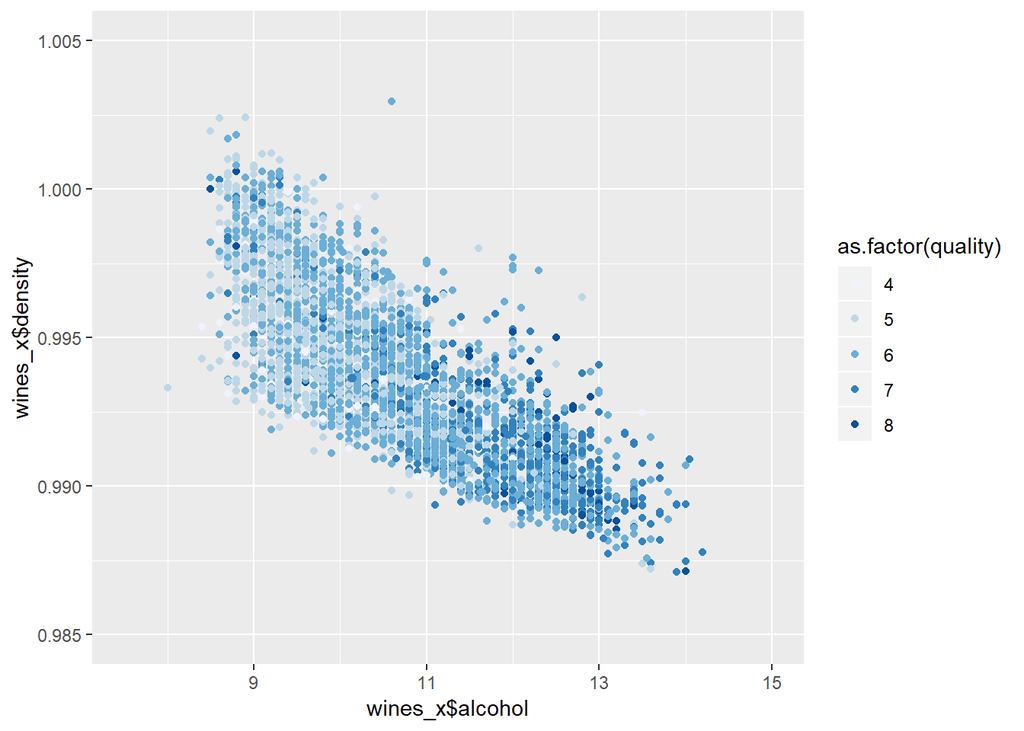

This graph shows higher alcohol containing white wines tend to have better quality.

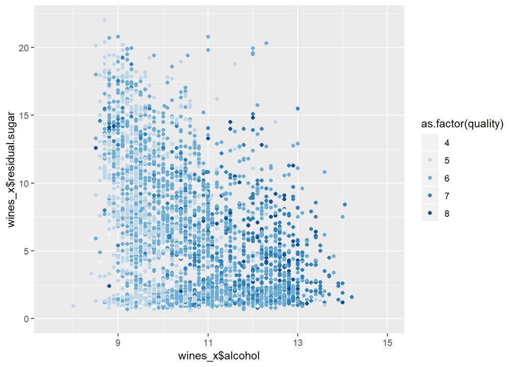

This graph shows the relation between alcohol and residual sugar. At same sugar levels wines containing more alcohol tend to have better quality.

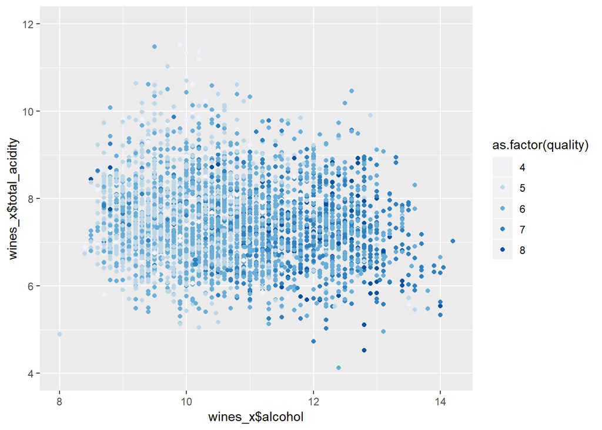

This graph shows relation between alcohol and total_acidity. At same total_acidity levels wines containing more alcohol tend to have better quality.

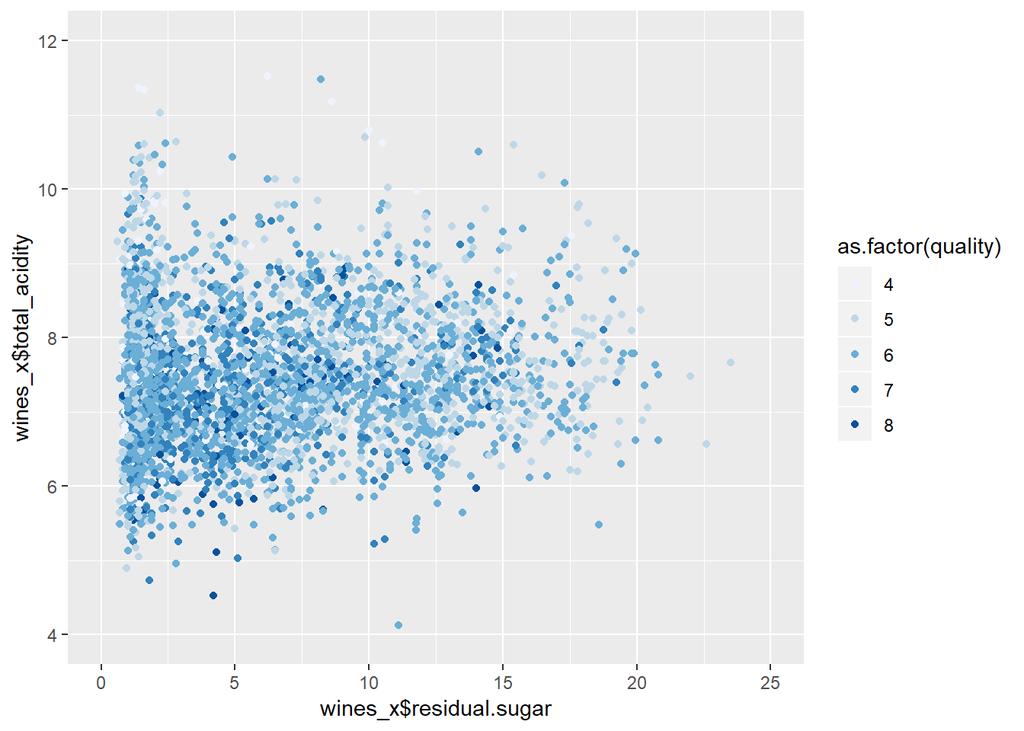

```
##
## Calls:
## w1: lm(formula = quality ~ alcohol + residual.sugar + total_acidity,
##     data = wines_x)
##
## ================================
##   (Intercept)         2.708***
##                      (0.152)
##   alcohol             0.346***
##                      (0.010)
##   residual.sugar      0.023***
##                      (0.002)
##   total_acidity      -0.080***
##                      (0.013)
## --------------------------------
##   R-squared           0.216
##   adj. R-squared      0.215
##   sigma               0.764
##   F                 445.984
##   p                   0.000
##   Log-likelihood  -5602.935
##   Deviance         2844.581
##   AIC             11215.869
##   BIC             11248.326
##   N                4873
## ================================
```

Tried to create a mathematical model based on alcohol, residual.sugar, and total_acidity levels. Value of R-squared is 0.216 which is very low. As a result, a more viable model requires examining more variables and in-depth chemistry knowledge.

# Multivariate Analysis

### Talk about some of the relationships you observed in this part of the investigation. Were there features that strengthened each other in terms of looking at your feature(s) of interest?

My significant finding is the importance of alcohol level in white wines. At higher alcohol levels the chance of getting a high-quality wine increases dramatically. Density which is highly correlated with residual sugar is lower at better quality wines.

### Were there any interesting or surprising interactions between features?

I would expect acidity which is a crucial variable of taste to have more impact on quality.

### OPTIONAL: Did you create any models with your dataset? Discuss the strengths and limitations of your model.

## I created a model and tried to find a relation between quality with sweetness, acidity, and alcohol. The model didn`t perform well.

# Final Plots and Summary

### Plot One

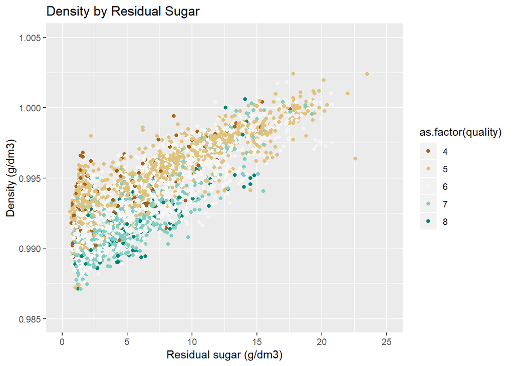

### Plot Two

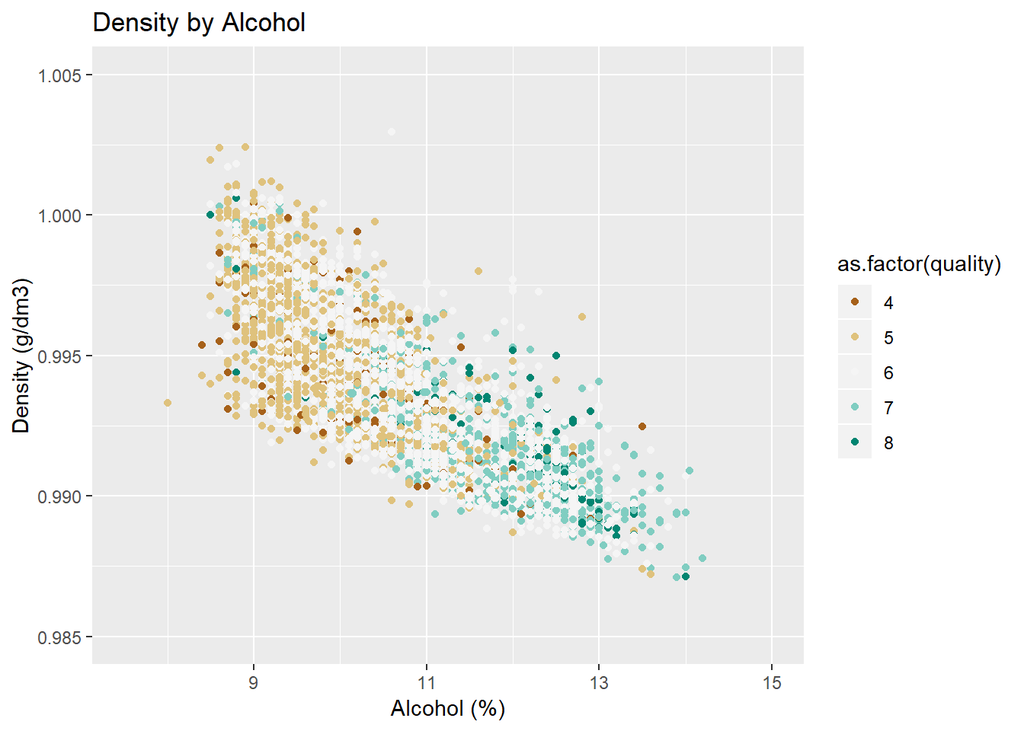

### Description Two

Alcohol is one of the significant factors of quality. In this graph, we see the decrease in density as alcohol increases. Better quality wines have lower density level and higher alcohol percent.

### Plot Three

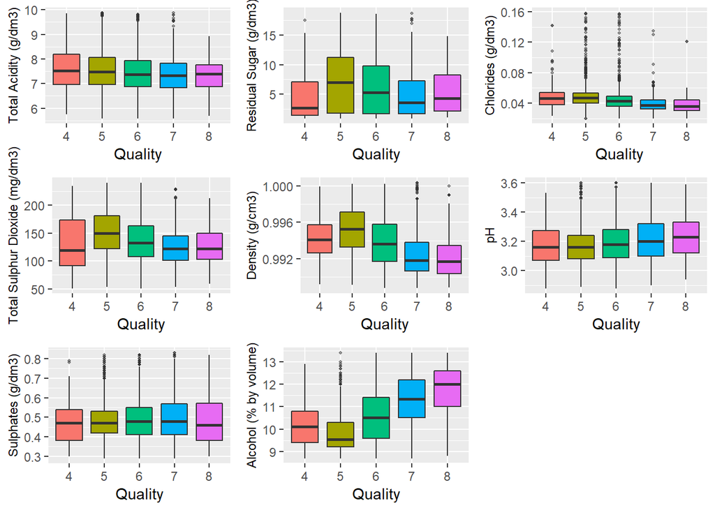

### Description Three

I plotted this graphs to have an idea about other variables found in white wine. The quality of white wine has a negative correlation with

-Total Acidity -Chlorides -Density -Total Sulphur Dioxide -Residual Sugar

positive correlation with

-pH -Alcohol -Sulfates ——

# Reflection

In this analysis, I examined a dataset related to the quality of white wine. Variables of this study are, Fixed Acidity, Volatile Acidity, Citric Acid, Chlorides, Density, Total Sulphur Dioxide, Residual Sugar, pH, Alcohol, Sulphates, Quality. I analyzed the relationship between all of the variables. I grouped variables by two.

Later I started to examine the interaction between variables. After calculating the correlations, I plotted the highest correlated variables. My primary interest was the quality which seemed like a result based on the other variables. Research findings suggested that alcohol, sweetness, and acidity were so crucial regarding the quality of the wine.

The model based on acidity, alcohol, and sweetness didn`t perform very well. The r-squared value was meager which was around 0.2. I concluded that quality measurement is more complicated, to get a more precise prediction of the wine quality, In my view, it requires in-depth chemistry knowledge and probably including more variables would be nice.